# analise-exploratoria-dos-dados-2016

Isabel

2025-11-24

# Introducao

Este relatorio apresenta uma analise exploratoria dos atributos florais da especie Oenothera ravenii obtidos no ano de 2016.

# As variaveis do conjunto de dados sao:

- id: identificador unico
- area: area floral
- tubo: comprimento do tubo floral
- nsem: numero de sementes

# Descricao

# Carregamento dos dados

```r
library(tidyverse) # biblioteca
df <- read.csv("dadosoenothera2016.csv") # criando o df

head(df) # visualizando os primeiros valores do DataFrame
```

```
##   id area tubo nsem
## 1  1 79.3  4.5   85
## 2  2 82.5  6.2   58
## 3  3 70.0  5.0  386
## 4  4 48.0  4.0  379
## 5  5 53.0  4.5  466
## 6  6 60.0  4.5  458
```

# dados faltantes

```r
glimpse(df)
```

```
## Rows: 77
## Columns: 4
## $ id   <int> 1, 2, 3, 4, 5, 6, 7, 8, 9, 10, 11, 12, 13, 14, 15, 16, 17, 18, 19…
## $ area <dbl> 79.3, 82.5, 70.0, 48.0, 53.0, 60.0, 59.5, 40.5, 76.0, 75.5, 52.3,…
## $ tubo <dbl> 4.5, 6.2, 5.0, 4.0, 4.5, 4.5, 5.0, 4.1, 5.2, 5.7, 4.0, 4.9, 4.1, …
## $ nsem <int> 85, 58, 386, 379, 466, 458, 250, 316, 315, 349, 353, 382, 451, 41…
```

```r
colSums(is.na(df))
```

```
##   id area tubo nsem
##    0    0    0    0
```

Nenhuma variável possui valores NA. A variável “nsem” apresenta zeros que representam ausência de atributo. Os zeros em “nsem” serão mantidos. Para 2016 não foram coletados os dados de germinação.

```r
df_clean <- df

  colSums(is.na(df_clean))
```

```
##   id area tubo nsem
##    0    0    0    0
```

```r
summary(df_clean)
```

```
##        id          area            tubo            nsem
##  Min.   : 1   Min.   :27.50   Min.   :3.100   Min.   :  0.0
##  1st Qu.:20   1st Qu.:52.80   1st Qu.:4.400   1st Qu.:229.0
##  Median :39   Median :61.50   Median :4.700   Median :349.0
##  Mean   :39   Mean   :61.24   Mean   :4.784   Mean   :300.5
##  3rd Qu.:58   3rd Qu.:70.00   3rd Qu.:5.100   3rd Qu.:386.0
##  Max.   :77   Max.   :88.30   Max.   :6.200   Max.   :466.0
```

```r
dfclean <- df
```

```r
estatisticas_2016  <- dfclean
```

```r
estatisticas_2016 <- dfclean %>%
  summarise(
media_area = mean(area, na.rm = TRUE),# media - area floral
sd_area = sd(area, na.rm = TRUE), # desvio padrao
media_tubo = mean(tubo, na.rm = TRUE), # media - comprimento
media_nsem = mean(nsem, na.rm = TRUE), # media - n. sementes
)
estatisticas_2016
```

```
##   media_area  sd_area media_tubo media_nsem
## 1   61.23896 13.08169   4.784416   300.4675
```

# visualizacao

## destribuicao das variaveis

```r
library(dplyr)
library(tidyr)
library(ggplot2)
```

```r
# Renomear variaveis sem acentos
df_clean_plot <- dfclean %>%
  rename(
    Area_mm2 = area,
    Comprimento_tubo_mm = tubo,
    Numero_sementes = nsem,
  )
```

```r
rm(estatisticas2016)
```

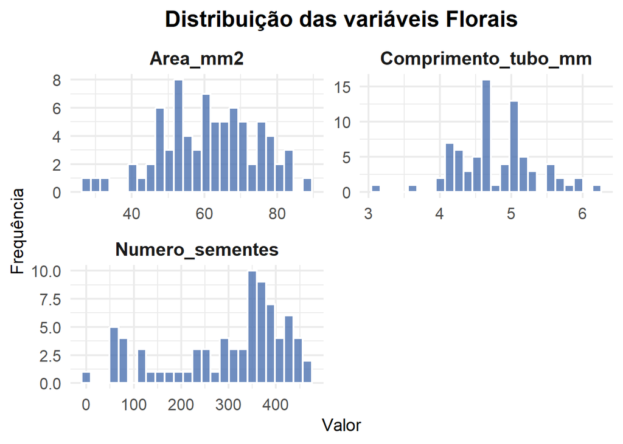

```r
df_clean_plot %>% # converte para o formato longo
  pivot_longer(
    cols = c(Area_mm2, Comprimento_tubo_mm, Numero_sementes),
    names_to = "Variavel",
    values_to = "Valor"
  ) %>%
  ggplot(aes(x = Valor)) + # inicia o grafico
  geom_histogram(
    bins = 25,
    fill = "#4C72B0",
    color = "white",
    alpha = 0.8
  ) +
  facet_wrap(~ Variavel, scales = "free", ncol = 2) + # um grafico para cada variavel
  labs(
    title = "Distribuição das variáveis Florais",
    x = "Valor",
    y = "Frequência"
  ) +
  theme_minimal(base_size = 16) +
  theme(
    plot.title = element_text(face = "bold", size = 18, hjust = 0.5),
    strip.text = element_text(size = 15, face = "bold"),
    axis.title.x = element_text(size = 14),
    axis.title.y = element_text(size = 14)
  )
```

Para o ano de 2016, o Comprimento do Tubo Floral apresentou a menor dispersão entre os dados. A Área Floral, por sua vez, manteve a ampla dispersão de 2015, apesar de sua distribuição se aproximar da simetria. O Número de Sementes também preservou o mesmo padrão de dispersão observado no ano anterior.

## relacao entre area floral e numero de sementes

Contrucao de um boxplot para visualizacao das variaveis area floral e numero de sementes

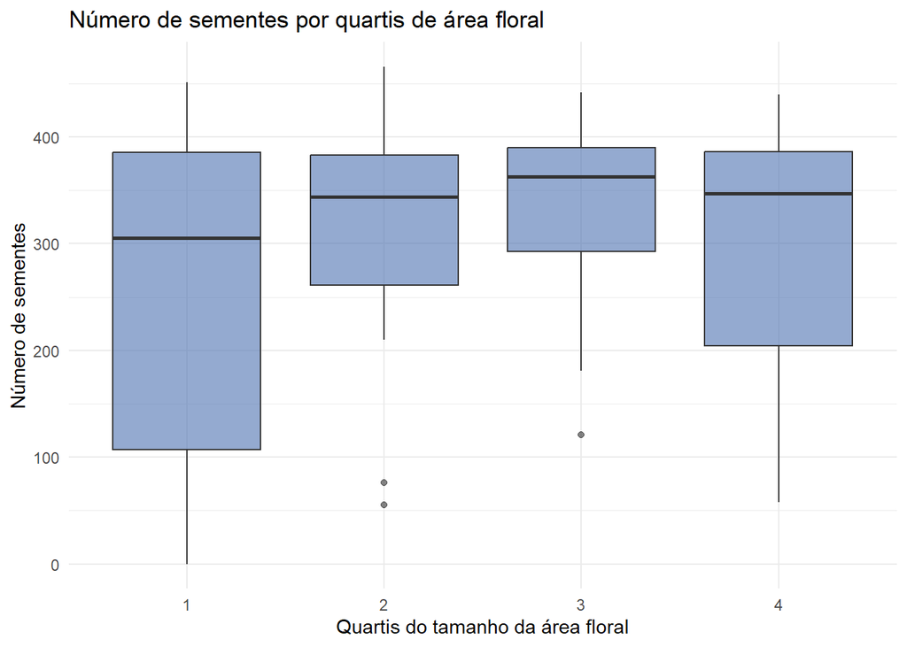

```r
dfclean %>%
  mutate(area = ntile(area, 4)) %>%   # divide em quartis
  ggplot(aes(x = factor(area), y = nsem)) +
  geom_boxplot(fill="#4C72B0", alpha=.6) +
  labs(
    x = "Quartis do tamanho da área floral",
    y = "Número de sementes",
    title = "Número de sementes por quartis de área floral"
  ) +
  theme_minimal()
```

Este gráfico compara a distribuição da variável Número de sementes (no eixo Y) em função dos Quartis da área floral (no eixo X). A análise dos boxplots sugere uma relação positiva entre o tamanho da área floral e a quantidade de sementes. Porém, não o suficiente para considerar o tamanho da flor um fator limitante para a quantidade de sementes produzidas. Os dados para o ano de 2016 são consistentes com os observados para o ano de 2015; quando foi observado que o tamanho da flor, embora relevante, não é um fator crucial para o sucesso de germinação.

## Relação entre comprimento do tubo floral e número de sementes

Construção de um boxplot para visualização das duas variáveis: “Comprimento do tubo floral” e “Número de sementes”

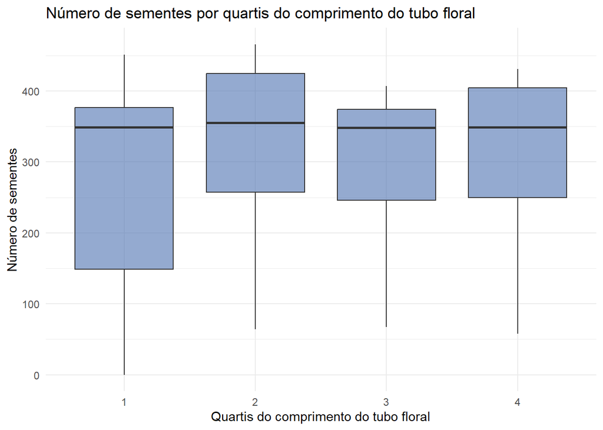

```r
dfclean %>%
  mutate(tubo = ntile(tubo, 4)) %>%   # divide em quartis
  ggplot(aes(x = factor(tubo), y = nsem)) +
  geom_boxplot(fill="#4C72B0", alpha=.6) +
  labs(
    x = "Quartis do comprimento do tubo floral",
    y = "Número de sementes",
    title = "Número de sementes por quartis do comprimento do tubo floral"
  ) +
  theme_minimal()
```

O comprimento do tubo floral não parece ser um fator limitante para a quantidade de sementes, já que o número de sementes mediano é o mesmo em todos os tamanhos de tubos. Embora tubos curtos (Q1) mostrem maior variação, o potencial de produção de sementes é mantido, independente do comprimento do tubo. Sugerindo que a limitação reprodutiva vem de um fator que não tem a ver nem com o comprimento do tubo, nem com a área da flor.